# Data Science Lecture 2, Exercise B

First, I read Chapter 5 of R for Data Science.

```r
library(tidyverse)
library(dplyr)
```

Exploratory Data Analysis (**“EDA”**) is fundamentally a creative process. And like most creative processes, the key to asking *quality* questions is to generate a large *quantity* of questions.

There is no rule about which questions you should ask to guide your research. However, two types of questions will always be useful for making discoveries within your data. You can loosely word these questions as:

1. What type of variation occurs within my variables?
2. What type of covariation occurs between my variables?

```r
ggplot(data = diamonds) +
  geom_bar(mapping = aes(x = cut))
```

[output not shown]

This can be computed manually or viewed as a table with dplyr::count()

```r
diamonds %>%
count(cut)
```

[output not shown]

If data is continuous, a histogram is useful.

```r
ggplot(data = diamonds) +
  geom_histogram(mapping = aes(x = carat), binwidth = 0.5)
```

[output not shown]

You can compute this by hand or pull a table with dplyr::count() and ggplot2::cut_width()

```r
diamonds %>%
  count(cut_width(carat, 0.5))
```

[output not shown]

You should always explore a variety of binwidths when working with histograms, as different binwidths can reveal different patterns.

```r
smaller <- diamonds %>%
  filter(carat<3)

ggplot(data = smaller, mapping = aes(x = carat)) +
  geom_histogram(binwidth = 0.1)
```

[output not shown]

If you wish to overlay multiple histograms in the same plot, use geom_freqpoly() instead of geom_histogram()

```r
smaller <- diamonds %>%
  filter(carat < 3)

ggplot(data = smaller, mapping = aes(x = carat, color = cut)) +
  geom_freqpoly(binwidth = 0.1)
```

[output not shown]

To make it easy to see the unusual values on a histogram, we need to zoom in to small values of the y-axis with coord_cartesian():

```r
ggplot(diamonds) +
  geom_histogram(mapping = aes(x = y), binwidth = 0.5) +
  coord_cartesian(ylim = c(0,50))
```

[output not shown]

ggplot2 also has xlim() and ylim() functions that work slightly differently: they throw away the data outside the limits.

This allows us to see that there are three unusual values: 0, ~30, and ~60. We pluck them out with dplyr:

```r
unusual <- diamonds %>%
  filter(y < 3 | y > 20) %>%
  arrange(y)

unusual
```

[output not shown]

It’s good practice to repeat your analysis with and without the outliers. If they have minimal effect on the results, and you can’t figure out why they’re there, it’s reasonable to replace them with missing values and move on. However, if they have a substantial effect on your results, you shouldn’t drop them without justification. You’ll need to figure out what caused them (e.g., a data entry error) and disclose that you removed them in your write-up.

Exercises

1. Explore the distribution of each of the x, y, and z variables in diamonds. What do you learn? Think about a diamond and how you might decide which dimension is the length, width, and depth.

```r
ggplot(diamonds) +
  geom_histogram(mapping = aes(x = x), binwidth = 0.5) +
  coord_cartesian(ylim = c(0,50))
ggplot(diamonds) +
  geom_histogram(mapping = aes(x = x), binwidth = 0.5)

ggplot(diamonds) +
  geom_histogram(mapping = aes(x = y), binwidth = 0.5) +
  coord_cartesian(ylim = c(0,50))
ggplot(diamonds) +
  geom_histogram(mapping = aes(x = y), binwidth = 0.5)

ggplot(diamonds) +
  geom_histogram(mapping = aes(x = z), binwidth = 0.5) +
  coord_cartesian(ylim = c(0,50))
ggplot(diamonds) +
  geom_histogram(mapping = aes(x = z), binwidth = 0.5)
```

[output not shown]

There are outliers in each direction that don’t make sense, so we have to deal with them. I would think x and y are length and width because their distributions look similar and diamonds are generally round or square.

2. Explore the distribution of price. Do you discover anything unusual or surprising? (Hint: carefully think about the binwidth and make sure you try a wide range of values.)

```r
ggplot(diamonds) +
  geom_histogram(mapping = aes(x = price))

ggplot(diamonds) +
  geom_histogram(mapping = aes(x = price), binwidth = 10)

ggplot(diamonds) +
  geom_histogram(mapping = aes(x = price), binwidth = 50)

ggplot(diamonds) +
  geom_histogram(mapping = aes(x = price), binwidth = 100)

ggplot(diamonds) +
  geom_histogram(mapping = aes(x = price), binwidth = 100) +
  coord_cartesian(ylim = c(0,100))

diamonds %>%
  count(cut_width(price, 100)) # surprising drop off at 1450 - 1550

ggplot(diamonds) +
  geom_histogram(mapping = aes(x = price), binwidth = 200)


ggplot(diamonds) +
  geom_histogram(mapping = aes(x = price), binwidth = 250)

diamonds %>%
  count(cut_width(price, 250)) # same drop off around 1500 is visible, but less so


ggplot(diamonds) +
  geom_histogram(mapping = aes(x = price), binwidth = 500)

diamonds%>%
  count(cut_width(price,500))

ggplot(diamonds) +
  geom_histogram(mapping = aes(x = price), binwidth = 100) +
  coord_cartesian(xlim = c(3500,6000))
```

[output not shown]

Surprising: huge count drop in the 1450-1550 price range small uptick around 4500 price range the price range is not continuous, as shown by the binwidth 10

3. How many diamonds are 0.99 carat? How many are 1 carat? What do you think is the cause of the difference?

```r
almost_1 <- diamonds %>%
  filter(carat == 0.99 | carat == 1) %>%
  arrange(carat)
ggplot(data = almost_1) +
  geom_histogram(mapping = aes(x = carat))

df <- data.frame(carat = c(0.99, 1),
                 count = c(length(which(diamonds$carat == 0.99)), length(which(diamonds$carat == 1))))
df # note, there has to be a better way to do this
```

[output not shown]

Almost no diamonds are 0.99 carats. This is probably due to market pressure where people look for a “1 carat” diamond.

4. Compare and contrast coord_cartesian() versus xlim() or ylim() when zooming in on a histogram. What happens if you leave binwidth unset? What happens if you try and zoom so only half a bar shows?

```r
ggplot(diamonds) +
  geom_histogram(mapping = aes(x = price), binwidth = 100) +
  coord_cartesian(ylim = c(0,100))

ggplot(diamonds) +
  geom_histogram(mapping = aes(x = price), binwidth = 100) +
  ylim(0,100)

ggplot(diamonds) +
  geom_histogram(mapping = aes(x = price)) +
  coord_cartesian(ylim = c(0,100))

ggplot(diamonds) +
  geom_histogram(mapping = aes(x = price)) +
  ylim(0,100)
```

[output not shown]

With a binwidth set, ylim removes those data points for x where the y that exceed my limit. With no binwidth, ylim removes almost everything.

## **Missing Values**

Replace the unusual values with missing values. The easiest way to do this is to use mutate() to replace the variable with a modified copy. You can use the ifelse() function to replace unusual values with NA

```r
diamonds2 <- diamonds %>%
  mutate(y = ifelse(y < 3 | y > 20, NA, y))


ggplot(data = diamonds2, mapping = aes(x = x, y = y)) +
  geom_point()
```

[output not shown]

If you want to know what makes items with missing variables different, you will want to mutate.

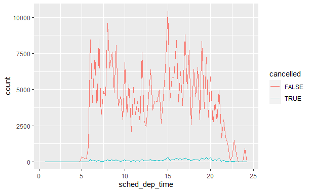

```r
nycflights13::flights %>%
  mutate(
    cancelled = is.na(dep_time),
    sched_hour = sched_dep_time %/% 100,
    sched_min = sched_dep_time %% 100,
    sched_dep_time = sched_hour + sched_min / 60
  ) %>%
  ggplot(mapping = aes(sched_dep_time)) +
    geom_freqpoly(
      mapping = aes(color = cancelled),
      binwidth = 1/4
    )
```

1. What happens to missing values in a histogram? What happens to missing values in a bar chart? Why is there a difference?

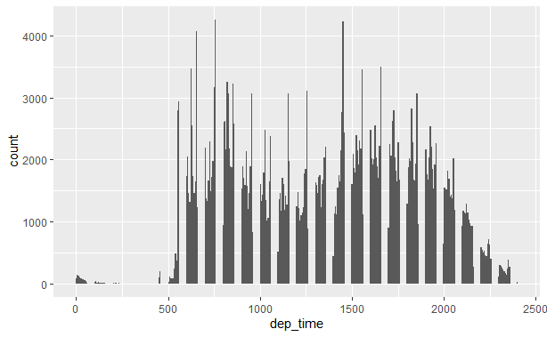

```r
ggplot(data = nycflights13::flights) +
  geom_histogram(mapping = aes(x = dep_time), binwidth = 6)
```

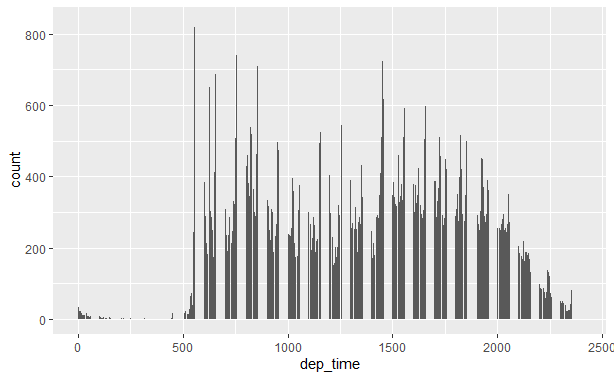

```r
ggplot(data = nycflights13::flights) +
  geom_bar(mapping = aes(x = dep_time))
```

In a histogram, they are removed.They are also removed in bar chart. I’m not sure what I am missing.

2. What does na.rm = TRUE do in mean() and sum()?

```r
sum(diamonds$price, na.rm = TRUE)
```

```
[1] 212135217
```

## Covariation

Instead of displaying the count, we want to display the *density*, which is the distribution.

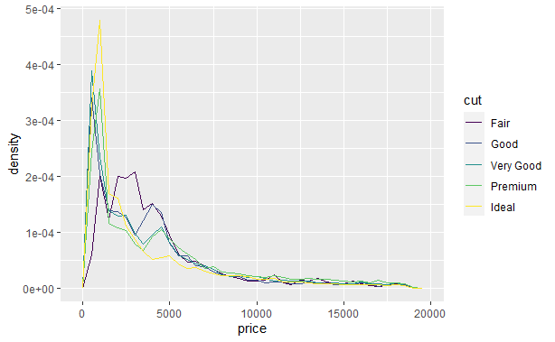

```r
ggplot(
  data = diamonds,
  mapping = aes(x = price, y = ..density..)
) +
  geom_freqpoly(mapping = aes(color = cut), binwidth = 500)
```

1. Use what you’ve learned to improve the visualization of the departure times of cancelled versus noncancelled flights.

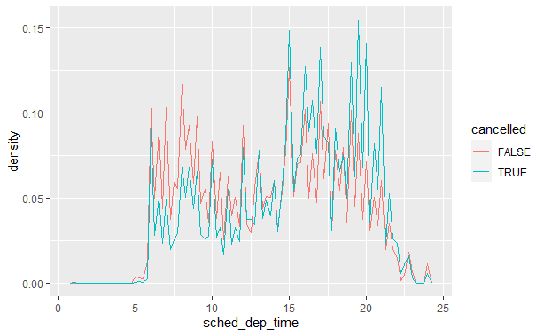

```r
nycflights13::flights %>%
  mutate(
    cancelled = is.na(dep_time),
    sched_hour = sched_dep_time %/% 100,
    sched_min = sched_dep_time %% 100,
    sched_dep_time = sched_hour + sched_min / 60
  ) %>%
  ggplot(mapping = aes(x = sched_dep_time, y = ..density..)) +
    geom_freqpoly(
      mapping = aes(color = cancelled),
      binwidth = 1/4
    )
```

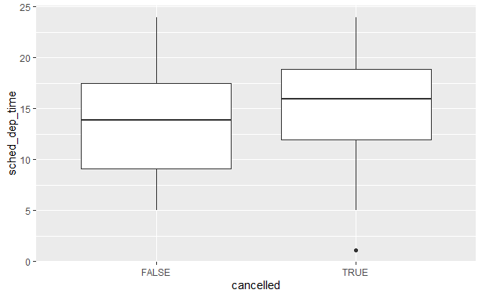

```r
nycflights13::flights %>%
  mutate(
    cancelled = is.na(dep_time),
    sched_hour = sched_dep_time %/% 100,
    sched_min = sched_dep_time %% 100,
    sched_dep_time = sched_hour + sched_min / 60
  ) %>%
  ggplot() +
    geom_boxplot(mapping = aes(x = cancelled, y = sched_dep_time))
```

2. What variable in the diamonds dataset is most important for predicting the price of a diamond? How is that variable correlated with cut? Why does the combination of those two relationships lead to lower quality diamonds being more expensive?